# Maternal Health

## Maternal Morality by Abortion Policy

Null hypothesis: the maternal mortality rate is the same across different abortion policies.

Alternative hypothesis: the maternal mortality rate in at least one abortion policy group is different from the rest.

```r
library(tidyverse)
df <- read_csv("../data/clean_data/merged_data.csv", show_col_types = FALSE)
df <- df[!is.na(df$abortion_policies), ]
df_test <- df[df$State != "US", ]
```

```r
df$abortion_policies <- factor(df$abortion_policies,
                              levels = c("most protective", "very protective",
                                         "protective", "some restrictions/protections",
                                         "restrictive", "very restrictive", "most restrictive"))
# Kruskal-Wallis test
kruskal.test(`maternal_mortality_rates_2020_2022_per_100,000_live births` ~ abortion_policies, data = df)
```

```
    Kruskal-Wallis rank sum test

data:  maternal_mortality_rates_2020_2022_per_100,000_live births by abortion_policies
Kruskal-Wallis chi-squared = 15.751, df = 6, p-value = 0.01516
```

```r
# If Kruskal-Wallis is significant, run pairwise Wilcoxon tests
pairwise.wilcox.test(df$`maternal_mortality_rates_2020_2022_per_100,000_live births`,
                     df$abortion_policies,
                     p.adjust.method = "bonferroni")
```

```
    Pairwise comparisons using Wilcoxon rank sum exact test

data:  df$`maternal_mortality_rates_2020_2022_per_100,000_live births` and df$abortion_policies

                              most protective very protective protective
very protective               1.00            -               -
protective                    1.00            1.00            -
some restrictions/protections 1.00            1.00            1.00
restrictive                   1.00            1.00            1.00
very restrictive              1.00            1.00            1.00
most restrictive              0.73            0.12            0.17
                              some restrictions/protections restrictive
very protective               -                             -
protective                    -                             -
some restrictions/protections -                             -
restrictive                   1.00                          -
very restrictive              1.00                          1.00
most restrictive              1.00                          1.00
                              very restrictive
very protective               -
protective                    -
some restrictions/protections -
restrictive                   -
very restrictive              -
most restrictive              1.00

P value adjustment method: bonferroni
```

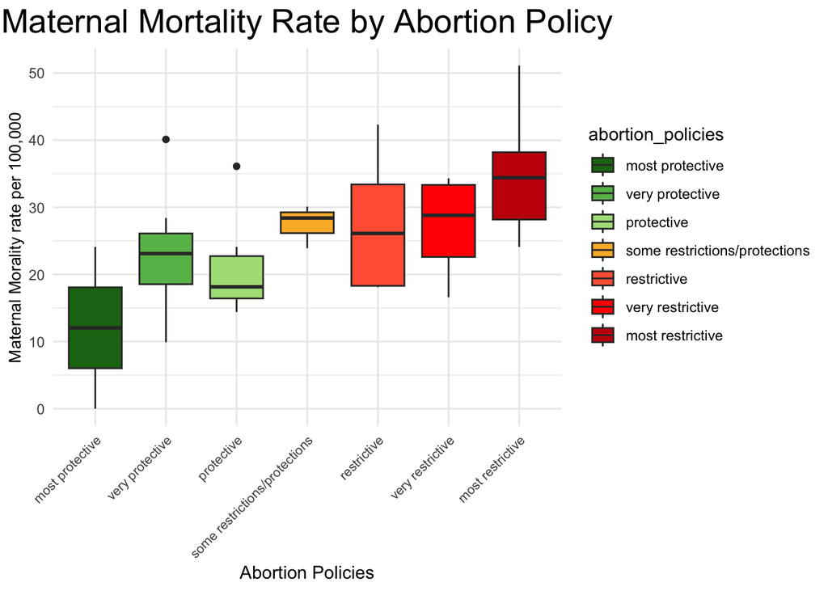

```r
# accompanying boxplot visualization
ggplot(df, aes(x = abortion_policies, y = `maternal_mortality_rates_2020_2022_per_100,000_live births`, fill=abortion_policies)) +
  geom_boxplot() +
  theme_minimal() +
  theme(axis.text.x = element_text(size = 8, angle = 45, hjust = 1),
        axis.title.y = element_text(size = 10)) +
  scale_fill_manual(values = c("#1c7416", "#68bb59", "#acdf87", "#fab733", "#ff6242", "#ff0000", "#c61a09")) +
  labs(x = "Abortion Policies",
       y = "Maternal Morality rate per 100,000",
       title = "Maternal Mortality Rate by Abortion Policy") +
  theme(plot.title = element_text(size = 20, hjust = 0.5))
```

```r
options(repos = c(CRAN = "https://cloud.r-project.org"))
install.packages("clinfun")
library(clinfun)

jt_test <- jonckheere.test(df$"maternal_mortality_rates_2020_2022_per_100,000_live births",
                          as.numeric(df$abortion_policies),
                          alternative="increasing",
                          nperm = 10000)
print(jt_test)
```

```
    Jonckheere-Terpstra test

data:
JT = 545, p-value = 1e-04
alternative hypothesis: increasing
```

To further confirm these findings, we will perform a permutation test on the ANOVA mean differences:

```r
# Permutation Test
N <- 10000

# Observed ANOVA F-statistic
observed_anova <- aov(`maternal_mortality_rates_2020_2022_per_100,000_live births` ~ abortion_policies, data = df)
observed_F <- summary(observed_anova)[[1]][["F value"]][1]

# Permutation loop
set.seed(1234)
perm_F <- numeric(N)

for (i in 1:N) {
  # Permute the response variable
  permuted_data <- df
  permuted_data$`maternal_mortality_rates_2020_2022_per_100,000_live births` <- sample(permuted_data$`maternal_mortality_rates_2020_2022_per_100,000_live births`)

  # Perform ANOVA on permuted data
  perm_anova <- aov(`maternal_mortality_rates_2020_2022_per_100,000_live births` ~ abortion_policies, data = permuted_data)
  perm_F[i] <- summary(perm_anova)[[1]][["F value"]][1]
}

# Calculate p-value
p_value <- mean(perm_F >= observed_F)

cat("Observed F-statistic:", observed_F, "\n")
```

```
Observed F-statistic: 3.595385
```

```r
cat("Permutation Test p-value:", p_value, "\n")
```

```
Permutation Test p-value: 0.0067
```

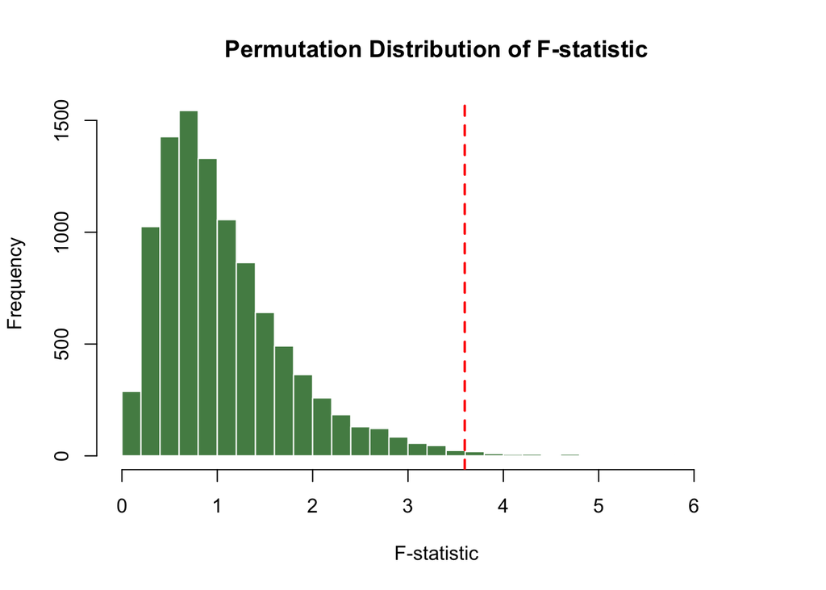

```r
# Plot the permutation F-statistics
hist(perm_F,
     breaks = 30,
     main = "Permutation Distribution of F-statistic",
     xlab = "F-statistic",
     col = "palegreen4",
     border = "white")

# F-statistic line
abline(v = observed_F,
       col = "red",
       lwd = 2,
       lty = 2)
```

The permutation test also yields a statistically significant p-value, further providing evidence to suggest a true mean difference in maternal mortality rates among abortion policy groups.

Abortions are critical for preserving maternal health and mortality. There are many situations in which an abortion is life-saving for the mother. By restricting or banning abortions, more mothers are at risk for maternal mortality by being prohibited or limited in accessing or being treated with necessary measures. If abortions are banned or heavily restricted, it is reasonable to assume that maternal mortality would increase in those states as more women suffer the effects of a complicated or terminal pregnancy without intervention. Additionally, prohibiting abortion forces women who aren’t ready to have babies to give birth, even if they are too young, facing other health risks or problems, or don’t have the financial resources or health insurance to access adequate care during pregnancy, which are all risk factors for maternal mortality.

When states choose to implement the restrictive abortion policies, even with data on maternal mortality in their state, they are consciously establishing conditions that could exacerbate preventable deaths in women.

## Women who Went Without Care due to Cost by Abortion Policy

Null hypothesis: the mean percentage of women who went without care because of cost is the same in each abortion policy group.

Alternative hypothesis: the mean percentage of women who went without care because of cost is different in at least one of the abortion policy groups.

```r
# Kruskal-Wallis test
kruskal.test(women_18_44_who_went_without_care_because_of_cost ~ abortion_policies, data = df)
```

```
    Kruskal-Wallis rank sum test

data:  women_18_44_who_went_without_care_because_of_cost by abortion_policies
Kruskal-Wallis chi-squared = 14.043, df = 6, p-value = 0.02916
```

```r
# If Kruskal-Wallis is significant, run pairwise Wilcoxon tests
pairwise.wilcox.test(df$women_18_44_who_went_without_care_because_of_cost,
                     df$abortion_policies,
                     p.adjust.method = "bonferroni")
```

```
    Pairwise comparisons using Wilcoxon rank sum test with continuity correction

data:  df$women_18_44_who_went_without_care_because_of_cost and df$abortion_policies

                              most protective very protective protective
very protective               1.00            -               -
protective                    1.00            1.00            -
some restrictions/protections 1.00            1.00            1.00
restrictive                   1.00            0.59            0.72
very restrictive              1.00            0.21            0.31
most restrictive              1.00            0.90            0.75
                              some restrictions/protections restrictive
very protective               -                             -
protective                    -                             -
some restrictions/protections -                             -
restrictive                   1.00                          -
very restrictive              1.00                          1.00
most restrictive              1.00                          1.00
                              very restrictive
very protective               -
protective                    -
some restrictions/protections -
restrictive                   -
very restrictive              -
most restrictive              1.00

P value adjustment method: bonferroni
```

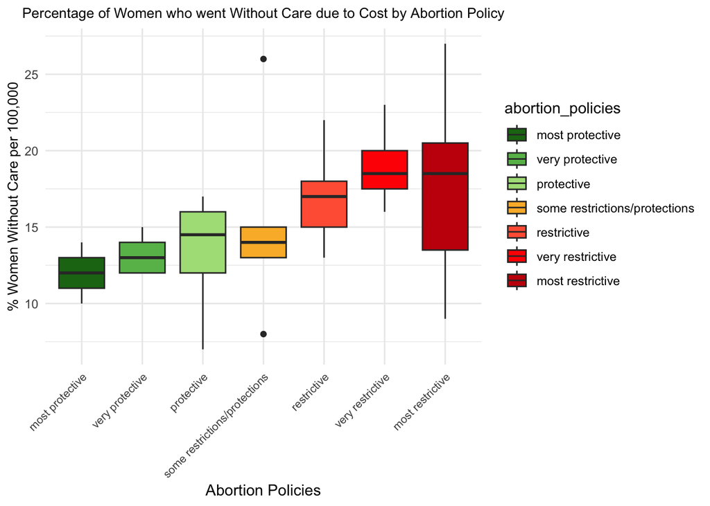

```r
# accompanying boxplot visualization
ggplot(df, aes(x = abortion_policies, y = women_18_44_who_went_without_care_because_of_cost, fill=abortion_policies)) +
  geom_boxplot() +
  theme_minimal() +
  theme(axis.text.x = element_text(size = 8, angle = 45, hjust = 1),
        axis.title.y = element_text(size = 10)) +
  scale_fill_manual(values = c("#1c7416", "#68bb59", "#acdf87", "#fab733", "#ff6242", "#ff0000", "#c61a09")) +
  labs(x = "Abortion Policies",
       y = "% Women Without Care per 100,000",
       title = "Percentage of Women who went Without Care due to Cost by Abortion Policy") +
  theme(plot.title = element_text(size = 10, hjust = 0.5))
```

```r
options(repos = c(CRAN = "https://cloud.r-project.org"))
install.packages("clinfun")
library(clinfun)

jt_test <- jonckheere.test(df$women_18_44_who_went_without_care_because_of_cost,
                          as.numeric(df$abortion_policies),
                          alternative="increasing",
                          nperm = 10000)
print(jt_test)
```

```
    Jonckheere-Terpstra test

data:
JT = 740.5, p-value = 4e-04
alternative hypothesis: increasing
```

To confirm the strength of the difference in means, we will perform a permutation test:

```r
# Permutation Test
N <- 10000

# Observed ANOVA F-statistic
observed_anova <- aov(women_18_44_who_went_without_care_because_of_cost ~ abortion_policies, data = df)
observed_F <- summary(observed_anova)[[1]][["F value"]][1]

# Permutation loop
set.seed(1234)
perm_F <- numeric(N)

for (i in 1:N) {
  # Permute the response variable
  permuted_data <- df
  permuted_data$women_18_44_who_went_without_care_because_of_cost <- sample(permuted_data$women_18_44_who_went_without_care_because_of_cost)

  # Perform ANOVA on permuted data
  perm_anova <- aov(women_18_44_who_went_without_care_because_of_cost ~ abortion_policies, data = permuted_data)
  perm_F[i] <- summary(perm_anova)[[1]][["F value"]][1]
}

# Calculate p-value
p_value <- mean(perm_F >= observed_F)

cat("Observed F-statistic:", observed_F, "\n")
```

```
Observed F-statistic: 2.329356
```

```r
cat("Permutation Test p-value:", p_value, "\n")
```

```
Permutation Test p-value: 0.0496
```

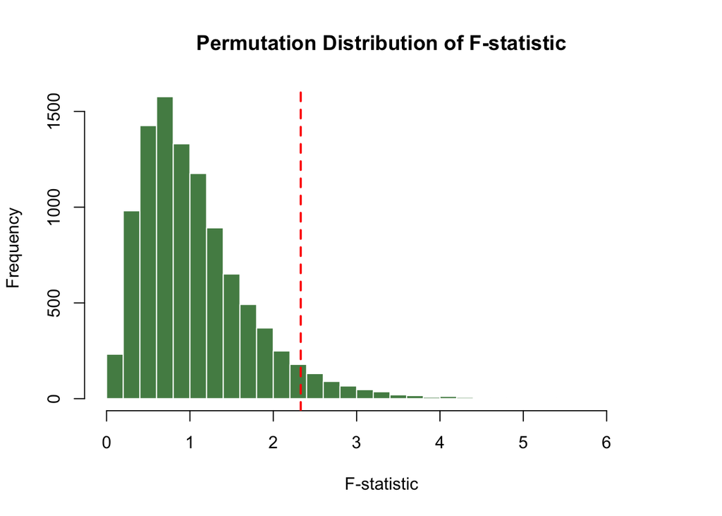

```r
# Plot the permutation F-statistics
hist(perm_F,
     breaks = 30,
     main = "Permutation Distribution of F-statistic",
     xlab = "F-statistic",
     col = "palegreen4",
     border = "white")

# F-statistic line
abline(v = observed_F,
       col = "red",
       lwd = 2,
       lty = 2)
```

These findings highlight how in states that chose to implement restrictive abortion bans, there were already problems with women being unable to access adequate maternal care due to costs. Adding restrictive abortion measures, which has indirect effects on the quality and accessibility of other maternal health resources, would add an extra layer of difficulty to women who need maternal care but aren’t able to afford it.